# EDA Tío Jorge

Realizaremos en análisis exploratorio de datos para conocer el comportamiento de nuestas variables.

```r
library(GGally)
library(tidyverse)
```

¿Todas las variables aportan al índice? ¿Qué variables aportan más? ¿Qué variables aportan menos?

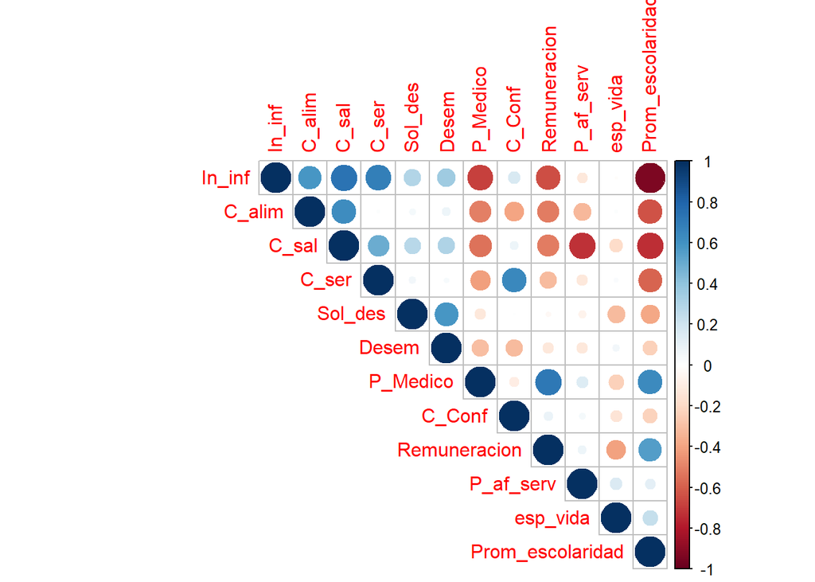

```
##
## Call:
## omcdiag(x = df.1[c(5, 8, 9, 10, 11, 12, 13)], y = df.1[1])
##
##
## Overall Multicollinearity Diagnostics
##
##                        MC Results detection
## Determinant |X'X|:         0.0358         0
## Farrar Chi-Square:        39.3971         1
## Red Indicator:             0.3580         0
## Sum of Lambda Inverse:    18.9482         0
## Theil's Method:            2.4540         1
## Condition Number:        143.0638         1
##
## 1 --> COLLINEARITY is detected by the test
## 0 --> COLLINEARITY is not detected by the test
```

Al ver que muchas de estas variables no aprotaran variabilidad a nuestro indice, decidimos categorizar las variables para obtener visualizaciones que nos ayuden mas.

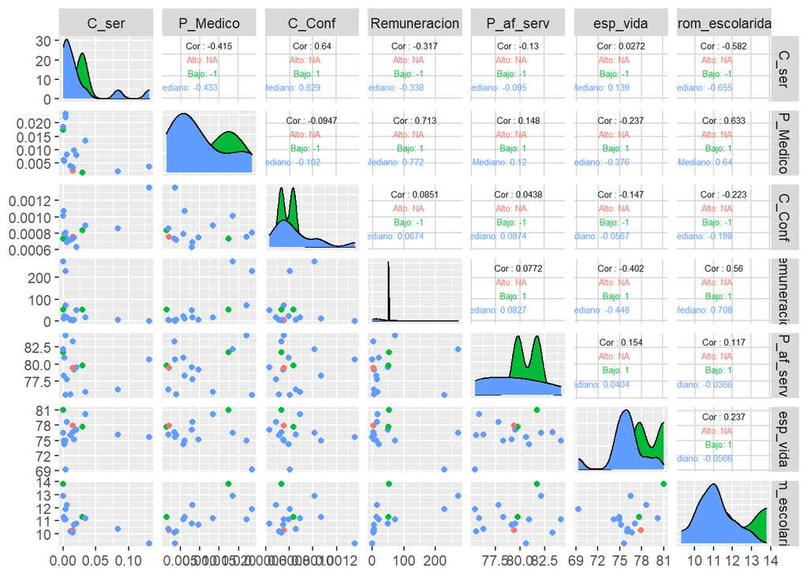

```r
df.3 %>% ggpairs(columns = c(2:8),upper = list(continuous = wrap('cor',size = 2)),  mapping = aes(color = Desem))
```

Veamos cómo se comportan los datos.

¿Qué grupo de desempleo tiene la remuneración más baja?

Realizamos una gráfica de brazos y caja para conocer la distribución de las remuneraciones para cada nivel de desempleo. Encontramos outliers solo para la categoría de desempleo medio y, cómo era de esperarse, la media más baja de remuneraciones es para la categoría de desempleo alto.

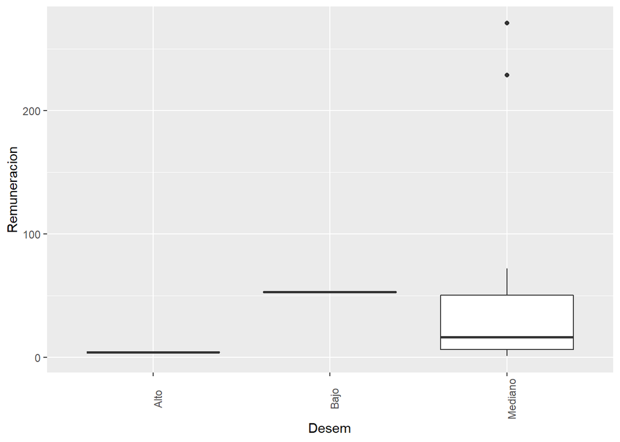

¿Qué grupo de desempleo tiene más varianza en la esperanza de vida? Ahora queremos ver las observaciones de esperanza de vida para cada grupo de desempleados. Encontramos que la CDMX es una región dónde la mayoría de las delegaciones tienen desempleo medio y a su vez la esperanza de vida más variada.

```r
library(ggbeeswarm)
```

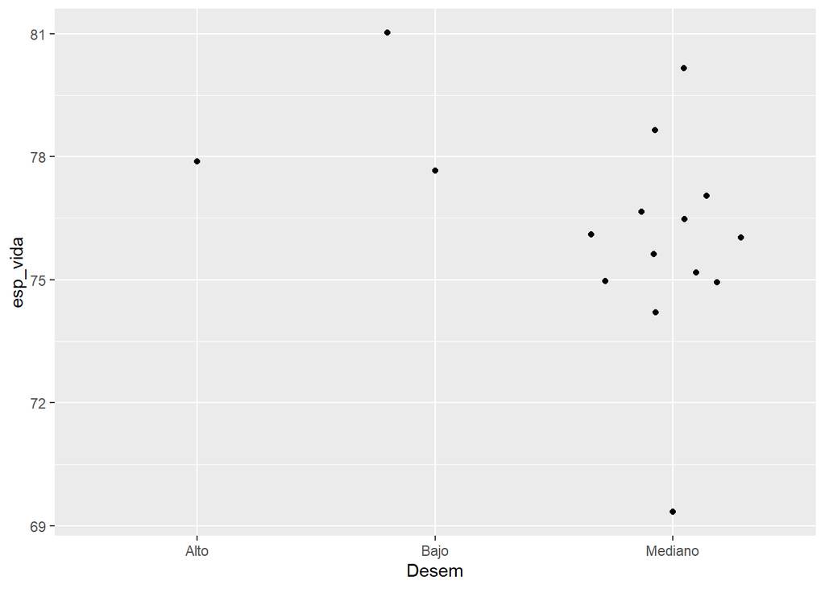

```r
ggplot(df.3,aes(Desem, esp_vida)) + geom_quasirandom()
```

¿Es el desempleo importante para determinar la esperanza de vida?

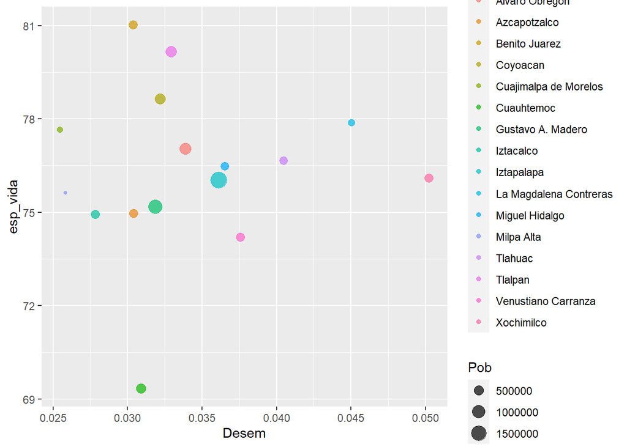

```r
library(dplyr)
ggplot(df, aes(x=Desem, y=esp_vida, size = Pob, col=Alc)) +
    geom_point(alpha=0.7)
```

¿Y la remuneración?

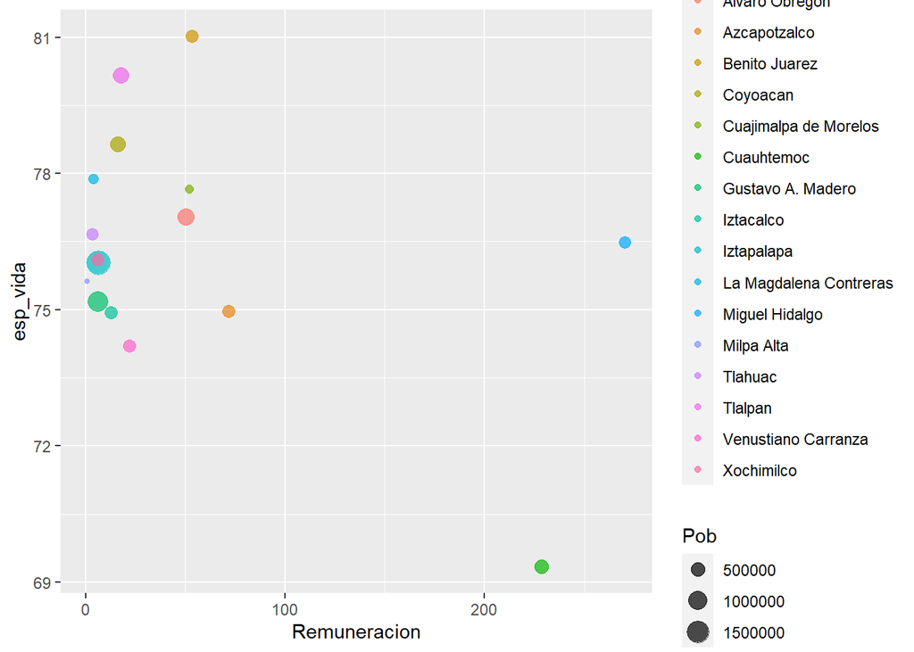

```r
library(dplyr)
ggplot(df, aes(x=Remuneracion, y=esp_vida, size = Pob, col=Alc)) +
    geom_point(alpha=0.7)
```